# 参数估计和假设检验

Humoon

2021-02-16

# 1 参数假设检验

已知随机变量分布类型时，对分布的参数进行的检验

## 1.1 对正态总体单样本的检验

### 1.1.1 单样本均值$\bar X$检验

#### 1.1.1.1 总体方差已知时：z检验

```
BSDA::z.test(
  x,
  y = NULL,
  alternative = "two.sided",
  mu = 0,
  sigma.x = NULL,
  sigma.y = NULL,
  conf.level = 0.95
)
```

- x，y 为样本数据。如果只提供 x，则作单个正态总体的期望估计；如果也提供 y，则作两个正态总体的期望估计。
- alternative 选择检验类型：
  - two.sided 表示双边检验($H_1: μ ≠ μ_0$)
  - less 表示左侧检验($H_1: μ < μ_0$)
  - greater 表示右侧检验($H_1: μ > μ_0$)
- mu表示原假设的$μ_0$值，根据alternative的不同，原假设分别为：
  - $H_0: μ = μ_0$
  - $H_0: μ \geq μ_0$
  - $H_0: μ \leq μ_0$
- sigma.x，sigma.y为总体标准差
- conf.level 置信水平，即$1-α$，通常是 0.95. $\alpha$表示犯第一类错误的概率，即原假设为真而拒绝原假设的概率。

检验结果是一个 htest 对象，包含八个分量。分别是

- `$statistic`, 统计量的值，即Z值，$Z=(\bar{X}-\mu)/(\sigma/\sqrt n)\sim N(0,1)$
- `$p.value`, p值，统计量所服从的分布曲线比Z值更极端的部分的面积。p<α时，拒绝原假设。
- `$conf.int`, $\bar{X}$在当前置信水平(conf.level)下的置信区间
- `$estimate`, 总体参数的估计值，即$\bar X$
- `$null.value`, 原假设中总体参数值，即$\mu_0$
- `$alternative`, 检验类型，双侧还是单侧
- `$method`, 检验方法，本例为z检验
- `$data.name`, 数据名称

```r
# 检验总体均值是否不等于5，已知总体方差为1
x <- c(4.89, 5.99, 5.89, 6.22, 4.79,
       5.47, 4.50, 6.61, 4.25, 6.67,
       4.46, 4.50, 6.97, 5.39, 4.56,
       5.03, 2.54, 5.27, 4.48, 4.05)
z <- z.test(x, mu = 5, sigma.x = 1)

class(z) # The class of z
```

```
# [1] "htest"
```

```r
str(z) # The structure of z
```

```
# List of 8
#  $ statistic  : Named num 0.566
#   ..- attr(*, "names")= chr "z"
#  $ p.value    : num 0.572
#  $ conf.int   : num [1:2] 4.69 5.56
#   ..- attr(*, "conf.level")= num 0.95
#  $ estimate   : Named num 5.13
#   ..- attr(*, "names")= chr "mean of x"
#  $ null.value : Named num 5
#   ..- attr(*, "names")= chr "mean"
#  $ alternative: chr "two.sided"
#  $ method     : chr "One-sample z-Test"
#  $ data.name  : chr "x"
#  - attr(*, "class")= chr "htest"
```

```r
# The elements of z
for (i in 1:8) {
  z %>% extract(i) %>% print()
}
```

```
# $statistic
#         z
# 0.5657252
#
# $p.value
# [1] 0.5715806
#
# $conf.int
# [1] 4.688239 5.564761
# attr(,"conf.level")
# [1] 0.95
#
# $estimate
# mean of x
#    5.1265
#
# $null.value
# mean
#    5
#
# $alternative
# [1] "two.sided"
#
# $method
# [1] "One-sample z-Test"
#
# $data.name
# [1] "x"
```

```r
# 检验总体均值是否小于25
b <- c(22,24,21,24,23,24,23,22,21,25)
z.test(b,alternative = 'less', mu = 25, sigma.x = 2.4) #左侧检验
```

```
#
#   One-sample z-Test
#
# data:  b
# z = -2.767, p-value = 0.002829
# alternative hypothesis: true mean is less than 25
# 95 percent confidence interval:
#        NA 24.14836
# sample estimates:
# mean of x
#      22.9
```

#### 1.1.1.2 总体方差未知时：t检验

```
t.test(
  x,
  y = NULL,
  alternative = c("two.sided", "less", "greater"),
  mu = 0,
  paired = FALSE,
  var.equal = FALSE,
  conf.level = 0.95,
  ...
)
```

- x，y 为样本数据。如果只提供 x，则作单个正态总体的期望估计；如果也提供 y，则作两个正态总体的期望估计。
- alternative 选择检验类型：
  - two.sided 表示双边检验($H_1: μ ≠ μ_0$)
  - less 表示左侧检验($H_1: μ < μ_0$)
  - greater 表示右侧检验($H_1: μ > μ_0$)
- mu表示原假设的$μ_0$值，根据alternative的不同，原假设分别为：
  - $H_0: μ = μ_0$
  - $H_0: μ \geq μ_0$
  - $H_0: μ \leq μ_0$
- sigma.x，sigma.y为总体标准差
- conf.level 置信水平，即$1-α$，通常是 0.95
- paired 设置是否为成对检验
- var.equal 是逻辑变量，var.equal=TRUE 表示两样品方差相同，var.equal=FALSE 表示两样本方差不同。

```r
# 检验样本均值是否大于50
x = c(50.2,49.6,51.0,50.8,50.6,49.8,51.2,49.7,51.5,50.3,51.0,50.6)
t <- t.test(x, mu = 50, alternative = "two.sided")
# The elements of t
for (i in 1:length(t)) {
  t %>% extract(i) %>% print()
}
```

```
# $statistic
#        t
# 2.956441
#
# $parameter
# df
# 11
#
# $p.value
# [1] 0.01305814
#
# $conf.int
# [1] 50.13415 50.91585
# attr(,"conf.level")
# [1] 0.95
#
# $estimate
# mean of x
#    50.525
#
# $null.value
# mean
#   50
#
# $stderr
# [1] 0.1775784
#
# $alternative
# [1] "two.sided"
#
# $method
# [1] "One Sample t-test"
#
# $data.name
# [1] "x"
```

### 1.1.2 单样本方差$S^2$检验

由于$\chi^2=(n-1)S^2/\sigma^2 \sim \chi^2(n-1)$，因此$\sigma^2$的置信水平为$1-\alpha$的置信区间为
$$(\frac{(n-1)S^2}{\chi^2_{\alpha/2}(n-1)}, \frac{(n-1)S^2}{\chi_{1-\alpha/2}^2(n-1)})$$

R中没有方差检验的内置函数，因此需要自己编写

```r
# 单样本方差区间估计函数
chisq <- function(n, S_var, alpha) {
  c((n - 1) * S_var / qchisq(alpha / 2, df = n - 1, lower.tail = F),
    (n - 1) * S_var / qchisq(1 - alpha / 2, df = n - 1, lower.tail = F)
  ) %>% return()
}

# 单样本方差检验函数
chisq.var.test <- function(x, sigma_var, alpha) {
  n <- length(x)
  chi2 <- (n - 1) * var(x) / sigma_var
  p <- pchisq(chi2, n - 1)
  cat(str_c("p value = ", p, ", "))
  if (p < alpha) {
    cat("reject H0\n")
  } else{
    cat("cannot reject H0\n")
  }
}
```

```r
# 判断数据的方差是否等于1
data <- fread("./data/al4-4.csv")
chisq.var.test(data$syl, 1, 0.05) # p值极小，故拒绝原假设
```

```
# p value = 2.19469293597337e-09, reject H0
```

## 1.2 对正态总体双样本的检验

### 1.2.1 双样本方差检验

判断两个样本波动情况是否相同，称为方差齐性检验、F检验

```
var.test(
  x,
  y,
  ratio = 1,
  alternative = "two.sided",
  conf.level = 0.95,
  ...
)
```

```r
x1=c(24,29,39,40,32,32,31,44,37,37,50,28,24,48,25,40,32,34,35,41)
x2=c(44,34,36,38,30,30,35,38,40,46,38,35,38,36,38,40,34,37,40,46)
var.test(x1,x2)
```

```
#
#   F test to compare two variances
#
# data:  x1 and x2
# F = 2.9283, num df = 19, denom df = 19, p-value = 0.02385
# alternative hypothesis: true ratio of variances is not equal to 1
# 95 percent confidence interval:
#  1.159058 7.398216
# sample estimates:
# ratio of variances
#           2.928304
```

### 1.2.2 双样本均值的检验

#### 1.2.2.1 两独立样本t检验

作两样本均值检验的步骤：

1. 需要验证样本是否服从正态分布，即正态性检验。
2. 判断两个样本是否有相同的方差，可以根据方差齐性检验判别。
3. t检验判断均值
- `t.test(x1,x2,var.equal=T)`# 方差齐性条件满足时
- `t.test(x1,x2)` # 方差非齐性时

```r
# 两家基金公司旗下基金的价格有无明显差异
data <- fread("./data/al4-2.csv")
# 若方差相同
t.test(data$fa, data$fb, var.equal = TRUE, conf.level = 0.99)
```

```
#
#   Two Sample t-test
#
# data:  data$fa and data$fb
# t = 14.05, df = 78, p-value < 2.2e-16
# alternative hypothesis: true difference in means is not equal to 0
# 99 percent confidence interval:
#  24.54489 35.90511
# sample estimates:
# mean of x mean of y
#   135.175   104.950
```

```r
# 若方差不同
t.test(data$fa, data$fb, var.equal = F)
```

```
#
#   Welch Two Sample t-test
#
# data:  data$fa and data$fb
# t = 14.05, df = 63.405, p-value < 2.2e-16
# alternative hypothesis: true difference in means is not equal to 0
# 95 percent confidence interval:
#  25.92655 34.52345
# sample estimates:
# mean of x mean of y
#   135.175   104.950
```

#### 1.2.2.2 两配对样本t检验

两个配对样本来自同一总体。

```r
data <- fread("./data/al4-3.csv")
t <- t.test(data$qian, data$hou, paired = TRUE, conf.level = 0.95)
t
```

```
#
#   Paired t-test
#
# data:  data$qian and data$hou
# t = 12.431, df = 49, p-value < 2.2e-16
# alternative hypothesis: true difference in means is not equal to 0
# 95 percent confidence interval:
#  6.958186 9.641814
# sample estimates:
# mean of the differences
#                     8.3
```

## 1.3 比例假设检验

### 1.3.1 单样本比例检验

无内置函数

### 1.3.2 双样本比例检验

```
prop.test(
  x,
  n,
  p = NULL,
  alternative = c("two.sided", "less", "greater"),
  conf.level = 0.95,
  correct = TRUE
)
```

x为实际观测数向量，n为总数向量

例：广告是否对观众产生影响

| 态度 | 第一周 | 第二周 |
| --- | --- | --- |
| 喜欢 | 45 | 56 |
| 不喜欢 | 35 | 47 |

```r
prop.test(c(45,56),c(45+35,56+47))
```

```
#
#   2-sample test for equality of proportions with continuity correction
#
# data:  c(45, 56) out of c(45 + 35, 56 + 47)
# X-squared = 0.010813, df = 1, p-value = 0.9172
# alternative hypothesis: two.sided
# 95 percent confidence interval:
#  -0.1374478  0.1750692
# sample estimates:
#    prop 1    prop 2
# 0.5625000 0.5436893
```

```r
# p值为0.9，不拒绝原假设，即认为喜欢的比例没有发生显著变化
```

# 2 非参数假设检验

随机变量分布类型未知时，对随机变量的类型进行检验、对样本是否独立进行检验、对两个样本是否来自于同一个分布进行检验等

## 2.1 图示法（探索性数据分析）

验证样本是否来源于正态总体，称为正态性检验。除了直方图，还有QQ图等可以验证样本是否来源于正态总体： 以标准正态分布的分位数为横坐标，以处在相同百分位的样本分位数为纵坐标，把样本表现在直角坐标系中的散点。如果资料服从正态分布，则样本点应该呈一条围绕第一象限对角线的直线。

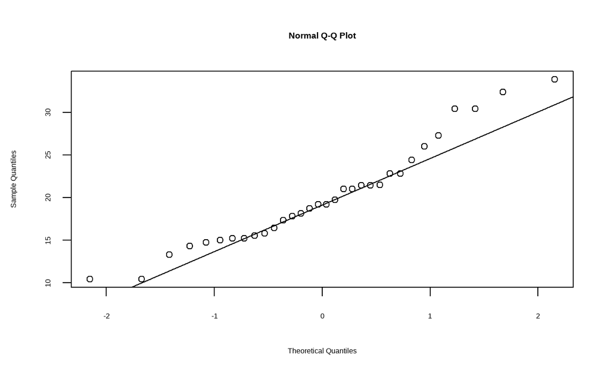

```r
attach(mtcars)
qqnorm(mtcars$mpg)
qqline(mtcars$mpg)
```

## 2.2 卡方检验

### 2.2.1 卡方拟合优度检验(Chi-squared goodness of fit tests)

检验样本是否符合某种特定分布

> chisq.test(x, y = NULL, correct = TRUE, p = rep(1/length(x), length(x)), rescale.p = FALSE, simulate.p.value = FALSE, B = 2000)

#### 2.2.1.1 离散型分布验证

实际分布是否符合理论分布

```r
freq=c(22,21,22,27,22,36)
probs=c(1,1,1,1,1,1)/6 #指定理论概率(多项分布)
chisq.test(freq,p=probs)
```

```
#
#   Chi-squared test for given probabilities
#
# data:  freq
# X-squared = 6.72, df = 5, p-value = 0.2423
```

#### 2.2.1.2 连续型分布验证

对于连续型分布的验证，本质是将其离散化，即分成相应的区域，通过每个区间的理论概率及频数构造统计量。

例: 验证男性身高是否服从N(170，64)

```r
x<-c(159.8,178.5,168.9,183.2,174.0,160.9,180.0,171.7,152.4,174.3,170.2,185.3,169.6,160.1,158.9,164.6,172.2,182.1,171.1)

fn=table(cut(x,breaks=c(min(x),160,170,180,190,max(x))))
F=pnorm(c(min(x),160,170,180,190,max(x)),170,8)
P=c(F[1],F[2]-F[1],F[3]-F[2],F[4]-F[3],1-F[4])
chisq.test(fn,p=P)
```

```
#
#   Chi-squared test for given probabilities
#
# data:  fn
# X-squared = 23.406, df = 4, p-value = 0.0001051
```

p值很小，拒绝原假设。男性身高不服从N(170，64)

注意：卡方拟合优度检验的检验结果依赖于分组，当不能拒绝原假设时，并不能说明原假设 就是正确的，特别是数据量不够大的时候。而且卡方检验是把连续数据转换成离散数据后进行检验 ，在转换过程中存在信息丢失，所以对卡方分布检验的结果需要小心。

### 2.2.2 卡方独立性检验(Chi-squared tests of independence)

检验列联表中的两个因子是否相互独立

| 受伤情况 | 无 | 轻微 | 较重 | 严重 |
| --- | --- | --- | --- | --- |
| 系安全带 | 12813 | 647 | 359 | 42 |
| 没系安全带 | 65963 | 4000 | 2642 | 303 |

```r
yesbelt=c(12813,647,359,42)
nobelt=c(65963,4000,2642,303)
chisq.test(rbind(yesbelt,nobelt))
```

```
#
#   Pearson's Chi-squared test
#
# data:  rbind(yesbelt, nobelt)
# X-squared = 59.224, df = 3, p-value = 8.61e-13
```

p值极小，拒绝原假设（独立）。因此两个变量不独立，即系安全带是有效果的。

### 2.2.3 卡方两样本同质性检验(Chi-squared tests for homogeneity)

检验各行是否来自同一个总体。

例： 通过使用sample命令，我们可以很容易地模拟抛掷一颗骰子。抛一个均匀的，再抛一个不均匀的，以测试卡方检验能否检验出它们的差别。

```r
set.seed(1234)
die.fair=sample(1:6,100,p=c(1,1,1,1,1,1)/6,rep=T) #均匀骰子
die.bias=sample(1:6,100,p=c(.5,.5,1,1,1,2)/6,rep=T) #不均匀骰子
res.fair=table(die.fair)
res.bias=table(die.bias)
count=rbind(res.fair,res.bias)
count
```

```
#           1  2  3  4  5  6
# res.fair 12 21 28  6 20 13
# res.bias 12  9 17 19 12 31
```

```r
chisq.test(count) # p值很小，拒绝原假设（同质骰子）
```

```
#
#   Pearson's Chi-squared test
#
# data:  count
# X-squared = 23.613, df = 5, p-value = 0.0002577
```

```r
chisq.test(count)$exp #获得期望频数
```

```
#           1  2    3    4  5  6
# res.fair 12 15 22.5 12.5 16 22
# res.bias 12 15 22.5 12.5 16 22
```

## 2.3 秩和检验

非参数检验通常是将数据转换成秩来进行分析的。一般来说，秩就是该数据按照升幂排列之后，每个观测值的位置。

### 2.3.1 单样本符号秩检验wilcox.test()

wilcoxon符号秩检验可以看成一种中位数检验

### 2.3.2 两独立秩和检验

两样本wilcoxon秩和检验也可由函数wilcox.test完成 该检验需要的唯一假定就是两个总体的分布有类似的形状，但不一定要求分布是对称的

### 2.3.3 多个独立样本的秩和检验

Kruskal-Wallis秩和检验为非参数检验，可在数据非正态的情况下代替单因素方差分析

例：对R自带的植物生长数据进行Kruskal-Wallis检验

```r
data(PlantGrowth)
head(PlantGrowth)
```

|  | weight | group |
| --- | --- | --- |
| 1 | 4.17 | ctrl |
| 2 | 5.58 | ctrl |
| 3 | 5.18 | ctrl |
| 4 | 6.11 | ctrl |
| 5 | 4.50 | ctrl |
| 6 | 4.61 | ctrl |

```r
kruskal.test(weight~group,data=PlantGrowth)
```

```
#
#   Kruskal-Wallis rank sum test
#
# data:  weight by group
# Kruskal-Wallis chi-squared = 7.9882, df = 2, p-value = 0.01842
```

```
#
#   Kruskal-Wallis rank sum test
#
# data:  scores by person
# Kruskal-Wallis chi-squared = 6.9383, df = 2, p-value = 0.03114
```

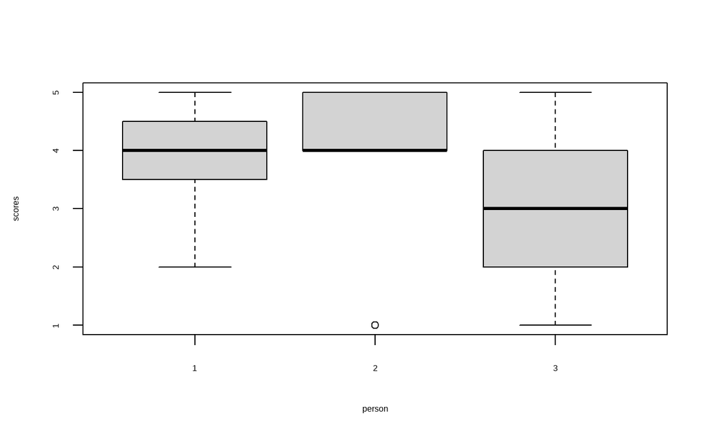

```r
scores=c(4,3,4,5,2,3,4,5,4,4,5,4,4,4,5,5,4,5,4,4,5,5,4,5,3,4,2,4,4,5,3,4,2,2,1,1)
person=c(1,1,1,1,1,1,1,1,1,1,1,1,2,2,2,2,2,2,2,2,2,2,2,2,3,3,3,3,3,3,3,3,3,3,3,2)
boxplot(scores~person)#做一个箱线图比较分布
kruskal.test(scores~person)
```

### 2.3.4 多个相关样本的秩和检验

```r
X=matrix(c(20.3,21.2,18.2,18.6,18.5,25.6,24.7,19.3,19.3,20.7,24.0,23.1,20.6,19.8,21.4) ,5)
friedman.test(X)
```

```
#
#   Friedman rank sum test
#
# data:  X
# Friedman chi-squared = 7.6, df = 2, p-value = 0.02237
```

## 2.4 K-S检验

### 2.4.1 K-S单样本总体分布验证

```r
x=rnorm(50)
y=runif(50,0,1)
ks.test(x,"pnorm",mean=0,sd=1)
```

```
#
#   One-sample Kolmogorov-Smirnov test
#
# data:  x
# D = 0.078771, p-value = 0.8915
# alternative hypothesis: two-sided
```

```r
ks.test(y,"punif",0,1)
```

```
#
#   One-sample Kolmogorov-Smirnov test
#
# data:  y
# D = 0.11342, p-value = 0.5049
# alternative hypothesis: two-sided
```

```r
ks.test(x,"pexp",0.5)
```

```
#
#   One-sample Kolmogorov-Smirnov test
#
# data:  x
# D = 0.53421, p-value = 7.394e-14
# alternative hypothesis: two-sided
```

### 2.4.2 K-S两独立样本同质检验

```
#
#   Two-sample Kolmogorov-Smirnov test
#
# data:  x1 and x2
# D = 0.6, p-value = 0.05465
# alternative hypothesis: two-sided
```

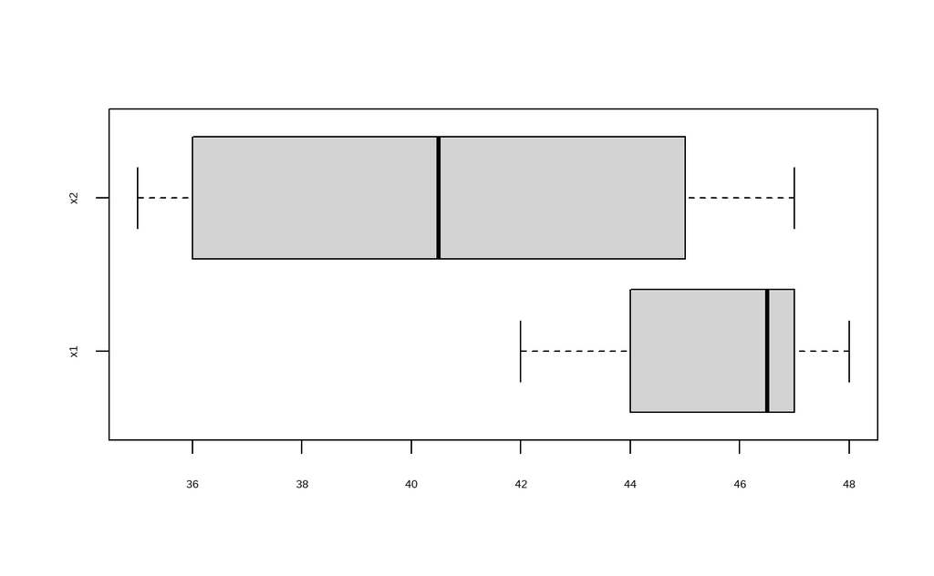

```r
x1=c(48,47,44,45,46,47,43,47,42,48)
x2=c(36,45,47,38,39,42,36,42,46,35)
boxplot(x1,x2,horizontal=T,names=c("x1","x2"))
ks.test(x1,x2)
```

## 2.5 常用正态性检验

### 2.5.1 偏度、峰度检验法